# Data Translation Assignment Question 3

# 3 Regression Discontinuity Analaysis (RDD) - Employment over Time

## 3.1 How has Employment Changed and How has COVID Affected Employment?

TRUE (teal-colored-line) shows the employment post cutoff COVID date. FALSE (red-colored-line) shows the employment pre cutoff COVID date.

The code below filters out data and employees who are not in the labor force. We then assign employed employees as 1 and unemployed employees as 0.

```r
empstatdf <- earnweekdf %>%
  filter(EMPSTAT > 09) %>%
  filter(EMPSTAT < 23)

# Filters out not in labor force, includes employed and unemployed

empstatdf <- empstatdf %>%
  mutate(EMPSTAT = replace(EMPSTAT, EMPSTAT == 10, 1)) %>%
  mutate(EMPSTAT = replace(EMPSTAT, EMPSTAT == 12, 1))
empstatdf <- empstatdf %>%
  mutate(EMPSTAT = replace(EMPSTAT, EMPSTAT == 20, 0)) %>%
  mutate(EMPSTAT = replace(EMPSTAT, EMPSTAT == 21, 0))

# Employed = 1, Unemployed = 0
```

By filtering out those not in the labor force and assigning a binary variable to those employed and unemployed, we can see how, on average, employment levels changed throughout the Pre-COVID and Post-COVID periods.

### 3.1.1 Retail Industry

```r
empstatdf1 <- empstatdf %>%
  filter(indname == 'Retail Trade')

m12 <- lm(EMPSTAT ~ Date * PostCOVID, data = empstatdf1)
export_summs(m12)
```

|  | Model 1 |
| --- | --- |
| (Intercept) | 0.70 *** |
|  | (0.04) |
| Date | 0.00 *** |
|  | (0.00) |
| PostCOVIDTRUE | -0.89 *** |
|  | (0.07) |
| Date:PostCOVIDTRUE | 0.00 *** |
|  | (0.00) |
| N | 323408 |
| R2 | 0.00 |
| *** p < 0.001; ** p < 0.01; * p < 0.05. |  |

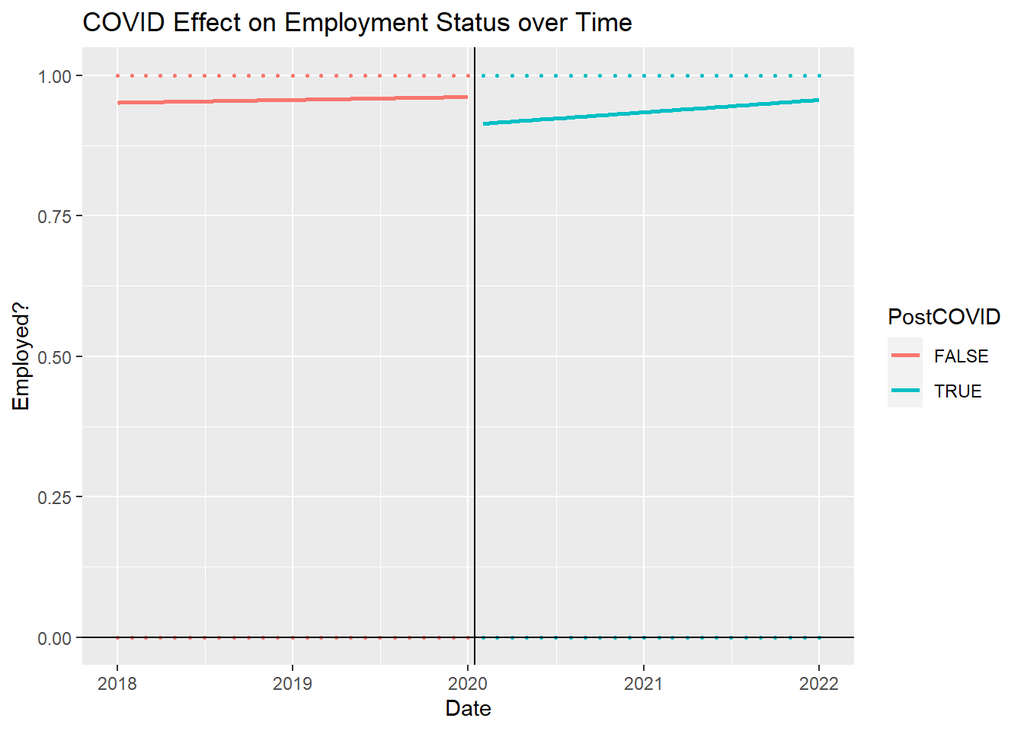

```r
empstatdf1 %>% mutate(date_group = as.factor(PostCOVID)) %>% ggplot(aes(x = Date, y = EMPSTAT, color = date_group)) + geom_point(size = 0.5) + geom_vline(xintercept = mdy(01152020)) + geom_smooth(method = "lm", se = FALSE) + ylim(0,1) + geom_hline(yintercept = 0) + labs(title = 'COVID Effect on Employment Status over Time', y = 'Employed?', color = 'PostCOVID')
```

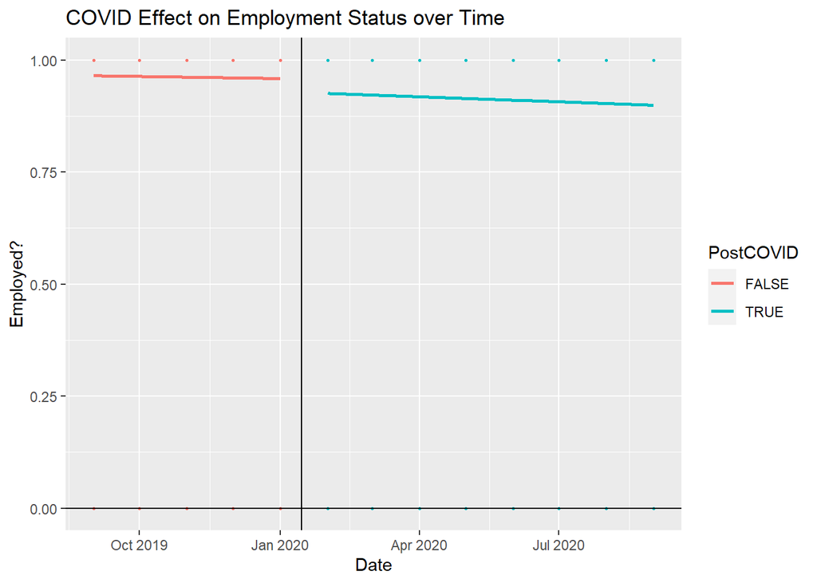

```r
empstatdf1 %>% mutate(date_group = as.factor(PostCOVID)) %>% ggplot(aes(x = Date, y = EMPSTAT, color = date_group)) + geom_point(size = 0.5) + geom_vline(xintercept = mdy(01152020)) + geom_smooth(method = "lm", se = FALSE) + ylim(0,1) + geom_hline(yintercept = 0) + labs(title = 'COVID Effect on Employment Status over Time', y = 'Employed?', color = 'PostCOVID') + xlim(mdy(09012019),mdy(09012020))
```

### 3.1.2 Professional, Scientific, and Management, and Administrative and Waste Management Services Industry

```r
empstatdf2 <- empstatdf %>%
  filter(indname == 'Professional, Scientific, and Management, and Administrative and Waste Management Services')

m13 <- lm(EMPSTAT ~ Date * PostCOVID, data = empstatdf2)
export_summs(m13)
```

|  | Model 1 |
| --- | --- |
| (Intercept) | 0.81 *** |
|  | (0.04) |
| Date | 0.00 *** |
|  | (0.00) |
| PostCOVIDTRUE | -0.49 *** |
|  | (0.06) |
| Date:PostCOVIDTRUE | 0.00 *** |
|  | (0.00) |
| N | 364525 |
| R2 | 0.00 |
| *** p < 0.001; ** p < 0.01; * p < 0.05. |  |

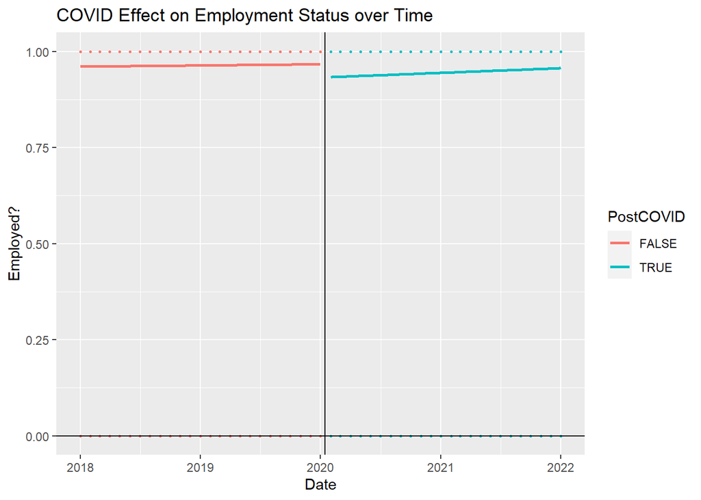

```r
empstatdf2 %>% mutate(date_group = as.factor(PostCOVID)) %>% ggplot(aes(x = Date, y = EMPSTAT, color = date_group)) + geom_point(size = 0.5) + geom_vline(xintercept = mdy(01152020)) + geom_smooth(method = "lm", se = FALSE) + ylim(0,1) + geom_hline(yintercept = 0) + labs(title = 'COVID Effect on Employment Status over Time', y = 'Employed?', color = 'PostCOVID')
```

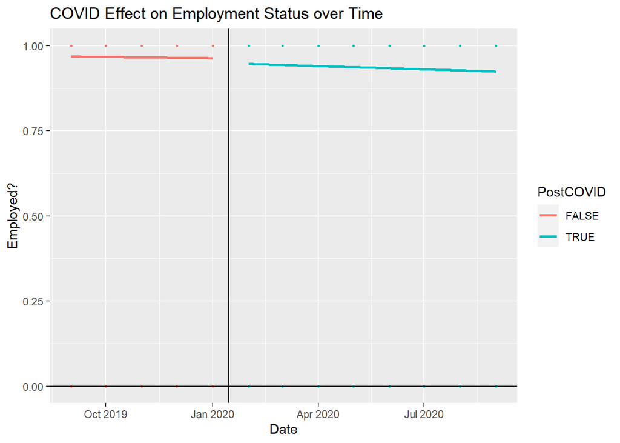

```r
empstatdf2 %>% mutate(date_group = as.factor(PostCOVID)) %>% ggplot(aes(x = Date, y = EMPSTAT, color = date_group)) + geom_point(size = 0.5) + geom_vline(xintercept = mdy(01152020)) + geom_smooth(method = "lm", se = FALSE) + ylim(0,1) + geom_hline(yintercept = 0) + labs(title = 'COVID Effect on Employment Status over Time', y = 'Employed?', color = 'PostCOVID') + xlim(mdy(09012019),mdy(09012020))
```

### 3.1.3 Finance and Insurance, and Real Estate and Rental and Leasing Industry

```r
empstatdf3 <- empstatdf %>%
  filter(indname == 'Finance and Insurance, and Real Estate and Rental and Leasing')

m14 <- lm(EMPSTAT ~ Date * PostCOVID, data = empstatdf3)
export_summs(m14)
```

|  | Model 1 |
| --- | --- |
| (Intercept) | 0.99 *** |
|  | (0.04) |
| Date | -0.00 |
|  | (0.00) |
| PostCOVIDTRUE | -0.38 *** |
|  | (0.06) |
| Date:PostCOVIDTRUE | 0.00 *** |
|  | (0.00) |
| N | 203380 |
| R2 | 0.00 |
| *** p < 0.001; ** p < 0.01; * p < 0.05. |  |

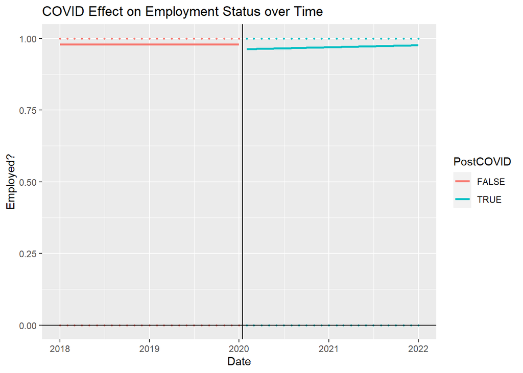

```r
empstatdf3 %>% mutate(date_group = as.factor(PostCOVID)) %>% ggplot(aes(x = Date, y = EMPSTAT, color = date_group)) + geom_point(size = 0.5) + geom_vline(xintercept = mdy(01152020)) + geom_smooth(method = "lm", se = FALSE) + ylim(0,1) + labs(title = 'COVID Effect on Employment Status over Time', y = 'Employed?', color = 'PostCOVID') + geom_hline(yintercept = 0)
```

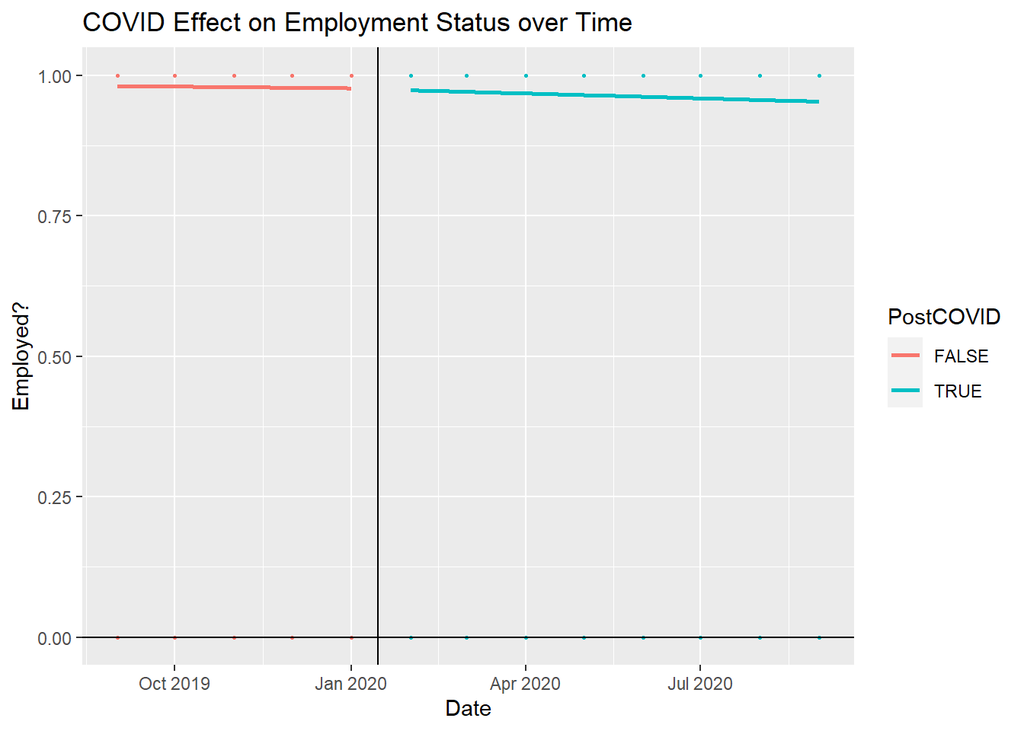

```r
empstatdf3 %>% mutate(date_group = as.factor(PostCOVID)) %>% ggplot(aes(x = Date, y = EMPSTAT, color = date_group)) + geom_point(size = 0.5) + geom_vline(xintercept = mdy(01152020)) + geom_smooth(method = "lm", se = FALSE) + ylim(0,1) + geom_hline(yintercept = 0) + labs(title = 'COVID Effect on Employment Status over Time', y = 'Employed?', color = 'PostCOVID') + xlim(mdy(09012019),mdy(09012020))
```